# Project_Group3

Machine Learning Final project

Home credit default risk

Data Science, Columbian College of Arts & Sciences, George Washington University

Author: Danlei Qian, Hung-chun Lin, Chen Chen

# Introduction

Home Credit B.V. is an international non-bank financial institution founded in 1997 in the Czech Republic and operates in 14 countries and focuses on lending primarily to people with little or no credit history. Home Credit strives to broaden financial inclusion for the unbanked population by providing a positive and safe borrowing experience. In order to predict the repayment ability of their customers, Home Credit held a Kaggle competition to see what sort of models the machine learning community can develop to help them in this task.

The objective of this project is to use historical loan application data to predict whether or not an applicant will be able to repay a loan. In this project, we will explore several models including Classification Models and Regression Models to predict the TARGET variable and Grid Search with combination of Pipeline for hyperparameter tuning.

## Data Source

Data source: https://www.kaggle.com/c/home-credit-default-risk

Since the raw dataset is too complex, we only use a part of the whole dataset - the application_train data(the main data with information about each loan application at Home Credit.) And every loan has its own row and is identified by the feature SK_ID_CURR(which is useless and we will drop it later).

The data comes with the TARGET indicating 0: the loan was repaid or 1: the loan was not repaid.

## Required packages

```python
import warnings
warnings.filterwarnings('ignore')
%matplotlib inline
```

```python
import pandas as pd
import numpy as np
#data preprocessing packages
from sklearn.preprocessing import Imputer
from sklearn.model_selection import train_test_split
from imblearn.over_sampling import RandomOverSampler
from imblearn.under_sampling import RandomUnderSampler
#model training packages
from sklearn.pipeline import Pipeline
from sklearn.base import BaseEstimator, ClassifierMixin
from sklearn.model_selection import GridSearchCV
from sklearn.model_selection import StratifiedKFold
from sklearn.model_selection import KFold
from sklearn.model_selection import cross_val_score
from sklearn.preprocessing import StandardScaler
from sklearn.linear_model import LogisticRegression
from sklearn.neural_network import MLPClassifier
from sklearn.ensemble import RandomForestClassifier
from sklearn.tree import DecisionTreeClassifier
from xgboost.sklearn import XGBClassifier
from sklearn.neighbors import KNeighborsClassifier
from sklearn.metrics import confusion_matrix
from sklearn.metrics import roc_auc_score
import scikitplot as skplt
import matplotlib.pyplot as plt
#Model selection packages
from IPython.display import Image
```

# Data preprocessing

The data has 307511 observations (each one a separate loan) and 122 features (variables) including the TARGET (the label we want to predict).

## Load data

```python
application = pd.read_csv("application_train.csv", header = 0)
application_predict = pd.read_csv("application_test.csv", header = 0)

print(application.shape)
print(application_predict.shape)
```

```
(307511, 122)
(48744, 121)
```

```python
application.head()
```

|  | SK_ID_CURR | TARGET | NAME_CONTRACT_TYPE | CODE_GENDER | FLAG_OWN_CAR | FLAG_OWN_REALTY | CNT_CHILDREN | AMT_INCOME_TOTAL | AMT_CREDIT | AMT_ANNUITY | ... | FLAG_DOCUMENT_18 | FLAG_DOCUMENT_19 | FLAG_DOCUMENT_20 | FLAG_DOCUMENT_21 | AMT_REQ_CREDIT_BUREAU_HOUR | AMT_REQ_CREDIT_BUREAU_DAY | AMT_REQ_CREDIT_BUREAU_WEEK | AMT_REQ_CREDIT_BUREAU_MON | AMT_REQ_CREDIT_BUREAU_QRT | AMT_REQ_CREDIT_BUREAU_YEAR |
| --- | --- | --- | --- | --- | --- | --- | --- | --- | --- | --- | --- | --- | --- | --- | --- | --- | --- | --- | --- | --- | --- |
| 0 | 100002 | 1 | Cash loans | M | N | Y | 0 | 202500.0 | 406597.5 | 24700.5 | ... | 0 | 0 | 0 | 0 | 0.0 | 0.0 | 0.0 | 0.0 | 0.0 | 1.0 |
| 1 | 100003 | 0 | Cash loans | F | N | N | 0 | 270000.0 | 1293502.5 | 35698.5 | ... | 0 | 0 | 0 | 0 | 0.0 | 0.0 | 0.0 | 0.0 | 0.0 | 0.0 |
| 2 | 100004 | 0 | Revolving loans | M | Y | Y | 0 | 67500.0 | 135000.0 | 6750.0 | ... | 0 | 0 | 0 | 0 | 0.0 | 0.0 | 0.0 | 0.0 | 0.0 | 0.0 |
| 3 | 100006 | 0 | Cash loans | F | N | Y | 0 | 135000.0 | 312682.5 | 29686.5 | ... | 0 | 0 | 0 | 0 | NaN | NaN | NaN | NaN | NaN | NaN |
| 4 | 100007 | 0 | Cash loans | M | N | Y | 0 | 121500.0 | 513000.0 | 21865.5 | ... | 0 | 0 | 0 | 0 | 0.0 | 0.0 | 0.0 | 0.0 | 0.0 | 0.0 |

5 rows × 122 columns

```python
application_predict.head()
#there is no target value in this data set
```

|  | SK_ID_CURR | NAME_CONTRACT_TYPE | CODE_GENDER | FLAG_OWN_CAR | FLAG_OWN_REALTY | CNT_CHILDREN | AMT_INCOME_TOTAL | AMT_CREDIT | AMT_ANNUITY | AMT_GOODS_PRICE | ... | FLAG_DOCUMENT_18 | FLAG_DOCUMENT_19 | FLAG_DOCUMENT_20 | FLAG_DOCUMENT_21 | AMT_REQ_CREDIT_BUREAU_HOUR | AMT_REQ_CREDIT_BUREAU_DAY | AMT_REQ_CREDIT_BUREAU_WEEK | AMT_REQ_CREDIT_BUREAU_MON | AMT_REQ_CREDIT_BUREAU_QRT | AMT_REQ_CREDIT_BUREAU_YEAR |
| --- | --- | --- | --- | --- | --- | --- | --- | --- | --- | --- | --- | --- | --- | --- | --- | --- | --- | --- | --- | --- | --- |
| 0 | 100001 | Cash loans | F | N | Y | 0 | 135000.0 | 568800.0 | 20560.5 | 450000.0 | ... | 0 | 0 | 0 | 0 | 0.0 | 0.0 | 0.0 | 0.0 | 0.0 | 0.0 |
| 1 | 100005 | Cash loans | M | N | Y | 0 | 99000.0 | 222768.0 | 17370.0 | 180000.0 | ... | 0 | 0 | 0 | 0 | 0.0 | 0.0 | 0.0 | 0.0 | 0.0 | 3.0 |
| 2 | 100013 | Cash loans | M | Y | Y | 0 | 202500.0 | 663264.0 | 69777.0 | 630000.0 | ... | 0 | 0 | 0 | 0 | 0.0 | 0.0 | 0.0 | 0.0 | 1.0 | 4.0 |
| 3 | 100028 | Cash loans | F | N | Y | 2 | 315000.0 | 1575000.0 | 49018.5 | 1575000.0 | ... | 0 | 0 | 0 | 0 | 0.0 | 0.0 | 0.0 | 0.0 | 0.0 | 3.0 |
| 4 | 100038 | Cash loans | M | Y | N | 1 | 180000.0 | 625500.0 | 32067.0 | 625500.0 | ... | 0 | 0 | 0 | 0 | NaN | NaN | NaN | NaN | NaN | NaN |

5 rows × 121 columns

## Remove feature 'ID' from the data

First, we drop the useless feature SK_ID_CURR(ID of loan in our sample).

```python
application = application.drop(columns=["SK_ID_CURR"])
application.shape
```

```
(307511, 121)
```

## Dealing with the missing value

Then, we can look at the number and percentage of missing values in each column.

### The missing value checker

```python
def missing_value_checker(df):
    """
    The missing value checker

    Parameters
    ----------
    df : dataframe

    Returns
    ----------
    The variables with missing value and their proportion of missing value
    """

    variable_proportion = [[variable, df[variable].isna().sum() / df.shape[0]]
                           for variable in df.columns
                           if df[variable].isna().sum() > 0]

    print('%-30s' % 'Variable with missing values', 'Proportion of missing values')
    for variable, proportion in sorted(variable_proportion, key=lambda x : x[1]):
        print('%-30s' % variable, proportion)

    return variable_proportion
```

### Identify variables with missing values

```python
variable_proportion = pd.DataFrame(missing_value_checker(application))
```

```
Variable with missing values   Proportion of missing values
DAYS_LAST_PHONE_CHANGE         3.2519161916159095e-06
CNT_FAM_MEMBERS                6.503832383231819e-06
AMT_ANNUITY                    3.9022994299390916e-05
AMT_GOODS_PRICE                0.0009040327012692228
EXT_SOURCE_2                   0.0021462646864665006
OBS_30_CNT_SOCIAL_CIRCLE       0.0033202064316398437
DEF_30_CNT_SOCIAL_CIRCLE       0.0033202064316398437
OBS_60_CNT_SOCIAL_CIRCLE       0.0033202064316398437
DEF_60_CNT_SOCIAL_CIRCLE       0.0033202064316398437
NAME_TYPE_SUITE                0.004201475719567756
AMT_REQ_CREDIT_BUREAU_HOUR     0.13501630835970097
AMT_REQ_CREDIT_BUREAU_DAY      0.13501630835970097
AMT_REQ_CREDIT_BUREAU_WEEK     0.13501630835970097
AMT_REQ_CREDIT_BUREAU_MON      0.13501630835970097
AMT_REQ_CREDIT_BUREAU_QRT      0.13501630835970097
AMT_REQ_CREDIT_BUREAU_YEAR     0.13501630835970097
EXT_SOURCE_3                   0.19825307062186392
OCCUPATION_TYPE                0.31345545362604915
EMERGENCYSTATE_MODE            0.47398304450897694
TOTALAREA_MODE                 0.4826851722377411
YEARS_BEGINEXPLUATATION_AVG    0.48781019215572774
YEARS_BEGINEXPLUATATION_MODE   0.48781019215572774
YEARS_BEGINEXPLUATATION_MEDI   0.48781019215572774
FLOORSMAX_AVG                  0.4976082156410665
FLOORSMAX_MODE                 0.4976082156410665
FLOORSMAX_MEDI                 0.4976082156410665
HOUSETYPE_MODE                 0.50176091261776
LIVINGAREA_AVG                 0.5019332641759157
LIVINGAREA_MODE                0.5019332641759157
LIVINGAREA_MEDI                0.5019332641759157
ENTRANCES_AVG                  0.503487680115508
ENTRANCES_MODE                 0.503487680115508
ENTRANCES_MEDI                 0.503487680115508
APARTMENTS_AVG                 0.5074972927797705
APARTMENTS_MODE                0.5074972927797705
APARTMENTS_MEDI                0.5074972927797705
WALLSMATERIAL_MODE             0.508407829313423
ELEVATORS_AVG                  0.532959796560123
ELEVATORS_MODE                 0.532959796560123
```

[output cut: 13 more lines]

```
YEARS_BUILD_MODE               0.6649778381911542
YEARS_BUILD_MEDI               0.6649778381911542
FLOORSMIN_AVG                  0.6784862980511266
FLOORSMIN_MODE                 0.6784862980511266
FLOORSMIN_MEDI                 0.6784862980511266
LIVINGAPARTMENTS_AVG           0.6835495315614726
LIVINGAPARTMENTS_MODE          0.6835495315614726
LIVINGAPARTMENTS_MEDI          0.6835495315614726
FONDKAPREMONT_MODE             0.6838617155158677
NONLIVINGAPARTMENTS_AVG        0.6943296337366793
NONLIVINGAPARTMENTS_MODE       0.6943296337366793
NONLIVINGAPARTMENTS_MEDI       0.6943296337366793
COMMONAREA_AVG                 0.6987229725115525
COMMONAREA_MODE                0.6987229725115525
COMMONAREA_MEDI                0.6987229725115525
```

```python
#get the column name with missing value over 50%
variable_proportion= variable_proportion.rename(columns={0:'Features',1:'Proportion'})
drop_colomns = variable_proportion.loc[variable_proportion.Proportion > 0.5].iloc[:,0].tolist()
drop_colomns
```

```
['OWN_CAR_AGE',
 'EXT_SOURCE_1',
 'APARTMENTS_AVG',
 'BASEMENTAREA_AVG',
 'YEARS_BUILD_AVG',
 'COMMONAREA_AVG',
 'ELEVATORS_AVG',
 'ENTRANCES_AVG',
 'FLOORSMIN_AVG',
 'LANDAREA_AVG',
 'LIVINGAPARTMENTS_AVG',
 'LIVINGAREA_AVG',
 'NONLIVINGAPARTMENTS_AVG',
 'NONLIVINGAREA_AVG',
 'APARTMENTS_MODE',
 'BASEMENTAREA_MODE',
 'YEARS_BUILD_MODE',
 'COMMONAREA_MODE',
 'ELEVATORS_MODE',
 'ENTRANCES_MODE',
 'FLOORSMIN_MODE',
 'LANDAREA_MODE',
 'LIVINGAPARTMENTS_MODE',
 'LIVINGAREA_MODE',
 'NONLIVINGAPARTMENTS_MODE',
 'NONLIVINGAREA_MODE',
 'APARTMENTS_MEDI',
 'BASEMENTAREA_MEDI',
 'YEARS_BUILD_MEDI',
 'COMMONAREA_MEDI',
 'ELEVATORS_MEDI',
 'ENTRANCES_MEDI',
 'FLOORSMIN_MEDI',
 'LANDAREA_MEDI',
 'LIVINGAPARTMENTS_MEDI',
 'LIVINGAREA_MEDI',
 'NONLIVINGAPARTMENTS_MEDI',
 'NONLIVINGAREA_MEDI',
 'FONDKAPREMONT_MODE',
 'HOUSETYPE_MODE',
 'WALLSMATERIAL_MODE']
```

### Drop the columns which missing proportion > 50%

And then we drop the features with over 50% missing values and then we have 80 columns left.

```python
print('Number of columns before removing columns with missing values over 50%:', str(application.shape[1]))
#drop the column with missing value over 50%
application_new = pd.DataFrame(application.drop(columns = drop_colomns, axis = 1))
print('Number of columns after removing columns with missing values over 50%:', str(application_new.shape[1]))
```

```
Number of columns before removing columns with missing values over 50%: 121
Number of columns after removing columns with missing values over 50%: 80
```

### Drop the rows with missing value less than 50%

To deal with the left missing values, here we simply drop the rows with missing values. Now, the data has 84575 observations (each one a separate loan) and 80 features (variables) including the TARGET (the label we want to predict).

```python
print('Number of rows before removing rows with missing values less than 50%:', str(application_new.shape[0]))

# Remove rows with np.NaN
application_new = application_new.dropna()

print('Number of rows after removing rows with missing values less than 50%:', str(application_new.shape[0]))
```

```
Number of rows before removing rows with missing values less than 50%: 307511
Number of rows after removing rows with missing values less than 50%: 84575
```

### Identify variables with missing values again

As you can see, we don’t have any missing values any more in our data.

```python
variable_proportion = missing_value_checker(pd.DataFrame(application_new))
```

```
Variable with missing values   Proportion of missing values
```

## Get the features and target

```python
X = application_new.drop(columns = ["TARGET"])
y = application_new["TARGET"]

feature_value_names = X.columns
```

## Handling categorical features and target

Since the machine learning models we will use below unfortunately cannot deal with categorical variables, we need to find a way to encode (represent) these variables as numbers before handing them off to the model. Here we use one-hot-encoding method.

Let's now look at the number of unique value in each of the categorical columns.

### The categorical feature checker

```python
def categorical_feature_checker(df, dtype):
    """
    The categorical feature checker

    Parameters
    ----------
    df : dataframe
    target : the target
    dtype : the type of the feature

    Returns
    ----------
    The categorical features and their number of unique value
    """

    feature_number = [[feature, df[feature].nunique()]
                      for feature in df.columns
                      if df[feature].dtype.name == dtype]

    print('%-30s' % 'Categorical feature', 'Number of unique value')
    for feature, number in sorted(feature_number, key=lambda x : x[1]):
        print('%-30s' % feature, number)

    return feature_number
```

### Identify categorical features

```python
feature_number = categorical_feature_checker(X,"object")
```

```
Categorical feature            Number of unique value
NAME_CONTRACT_TYPE             2
FLAG_OWN_CAR                   2
FLAG_OWN_REALTY                2
EMERGENCYSTATE_MODE            2
CODE_GENDER                    3
NAME_INCOME_TYPE               5
NAME_EDUCATION_TYPE            5
NAME_FAMILY_STATUS             5
NAME_HOUSING_TYPE              6
NAME_TYPE_SUITE                7
WEEKDAY_APPR_PROCESS_START     7
OCCUPATION_TYPE                18
ORGANIZATION_TYPE              57
```

### Encode categorical features

```python
# The categorical features
categorical_features = [feature for feature, number in feature_number]

# Encode the categorical features using One-hot-encoding
X = pd.get_dummies(data=X, columns=categorical_features)

feature_value_names = X.columns
```

```python
X.head()
```

|  | CNT_CHILDREN | AMT_INCOME_TOTAL | AMT_CREDIT | AMT_ANNUITY | AMT_GOODS_PRICE | REGION_POPULATION_RELATIVE | DAYS_BIRTH | DAYS_EMPLOYED | DAYS_REGISTRATION | DAYS_ID_PUBLISH | ... | ORGANIZATION_TYPE_Trade: type 5 | ORGANIZATION_TYPE_Trade: type 6 | ORGANIZATION_TYPE_Trade: type 7 | ORGANIZATION_TYPE_Transport: type 1 | ORGANIZATION_TYPE_Transport: type 2 | ORGANIZATION_TYPE_Transport: type 3 | ORGANIZATION_TYPE_Transport: type 4 | ORGANIZATION_TYPE_University | EMERGENCYSTATE_MODE_No | EMERGENCYSTATE_MODE_Yes |
| --- | --- | --- | --- | --- | --- | --- | --- | --- | --- | --- | --- | --- | --- | --- | --- | --- | --- | --- | --- | --- | --- |
| 0 | 0 | 202500.0 | 406597.5 | 24700.5 | 351000.0 | 0.018801 | -9461 | -637 | -3648.0 | -2120 | ... | 0 | 0 | 0 | 0 | 0 | 0 | 0 | 0 | 1 | 0 |
| 12 | 0 | 67500.0 | 80865.0 | 5881.5 | 67500.0 | 0.031329 | -13439 | -2717 | -311.0 | -3227 | ... | 0 | 0 | 0 | 0 | 0 | 0 | 0 | 0 | 1 | 0 |
| 13 | 1 | 225000.0 | 918468.0 | 28966.5 | 697500.0 | 0.016612 | -14086 | -3028 | -643.0 | -4911 | ... | 0 | 0 | 0 | 0 | 0 | 0 | 0 | 0 | 1 | 0 |
| 18 | 0 | 112500.0 | 157500.0 | 7875.0 | 157500.0 | 0.046220 | -17718 | -7804 | -8751.0 | -1259 | ... | 0 | 0 | 0 | 0 | 0 | 0 | 0 | 0 | 1 | 0 |
| 22 | 1 | 450000.0 | 497520.0 | 32521.5 | 450000.0 | 0.020713 | -11146 | -4306 | -114.0 | -2518 | ... | 0 | 0 | 0 | 0 | 0 | 0 | 0 | 0 | 1 | 0 |

5 rows × 187 columns

```python
y.value_counts()
```

```
0    78299
1     6276
Name: TARGET, dtype: int64
```

## Split data into Train and Test

Now, we can split our data into traing with percentage of 80 and testing with percentage of 20.

```python
#80% training set, 20% testing set
X_train, X_test, y_train, y_test = train_test_split(X, y, test_size=0.2, random_state=0, stratify=y)
```

### Check categorical target

As the bar chart shows, we get 62639 target'0' and 5021 target'1',the two classes are quitely imbalanced.

```python
# Print the unique value and their number for the target
y_train.value_counts()
```

```
0    62639
1     5021
Name: TARGET, dtype: int64
```

## Over sampling

Since most machine learning algorithms work best when the number of samples in each class are about equal, we need to deal with the imbalanced problem. Here we use over sampling method.

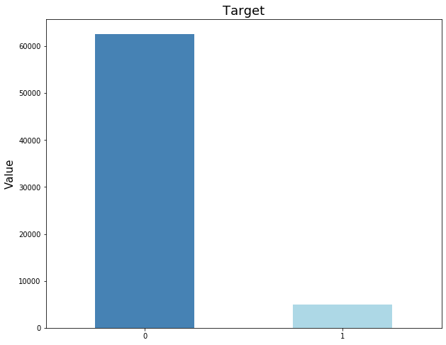

```python
#application_new.ix[:,'TARGET'].value_counts().plot(kind='bar',figsize=(10 ,8),width=0.5,colors=('steelblue','lightblue'))
y_train.value_counts().plot(kind='bar',figsize=(10 ,8),width=0.5,colors=('steelblue','lightblue'))
plt.xticks(rotation='horizontal')
plt.title('Target',fontsize=18)
plt.ylabel("Value",fontsize=15)
plt.show()
```

```python
# RandomOverSampler (with random_state=0)
ros = RandomOverSampler(random_state=0)
X_train, y_train = ros.fit_sample(X_train, y_train)

pd.DataFrame(data=y_train, columns=["TARGET"])["TARGET"].value_counts()
```

```
1    62639
0    62639
Name: TARGET, dtype: int64
```

```python
print(X_train.shape)
print(y_train.shape)
```

```
(125278, 187)
(125278,)
```

# Model Training

In this section, we first use the combination of Pipeline and GridSearchCV to fine tune the hyperparameters of 6 classifiers. For our training result, the scoring we choose to evaluate the model is f1 score, f1 score can convey the balance between the precision and the recall.

\begin{equation*} F1 = \frac{2(Recall)(Precision)}{(Recall)+(Precision)}\end{equation*}

In the training procedure, we also use cross-validation in the model training, the data is trained in 10 folds, so that we can get a more accurate result. After finished all the steps, we use confusion matrix, AUC and ROC to test the model to make sure the model could be used without low predicting power or overfitting ... etc.

## Logistic regression

#### For logistic regression, the hyperparameters we fine tune are: *multi_class, solver and C.*

```python
C_range = [10 ** i for i in range(-4, 5)]

param_grid = [{'Logisticregression__multi_class': ['ovr'],
               'Logisticregression__solver': ['newton-cg', 'lbfgs', 'liblinear', 'sag', 'saga'],
               'Logisticregression__C': C_range},

              {'Logisticregression__multi_class': ['multinomial'],
               'Logisticregression__solver': ['newton-cg', 'lbfgs', 'sag', 'saga'],
               'Logisticregression__C': C_range}]
```

```python
lr_pipe = Pipeline([('StandardScaler', StandardScaler()),
                    ('Logisticregression', LogisticRegression())])

lr_gs = GridSearchCV(estimator=lr_pipe,
                  param_grid=param_grid,
                  scoring='f1',
                  n_jobs=-1,
                  cv=StratifiedKFold(n_splits=10,shuffle=True,random_state=0))

lr_fitted = lr_gs.fit(X_train, y_train)


# Print the best settings
print('%-15s' % 'best_score:', lr_fitted.best_score_)
print('%-15s' % 'std:', lr_fitted.cv_results_["std_test_score"][lr_fitted.best_index_])
print('%-15s' % 'best_params:'.format(20), lr_fitted.best_params_, end='\n\n')
```

```
best_score:     0.6907899722968173
std:            0.0037082992431903125
best_params:    {'Logisticregression__C': 0.01, 'Logisticregression__multi_class': 'multinomial', 'Logisticregression__solver': 'newton-cg'}
```

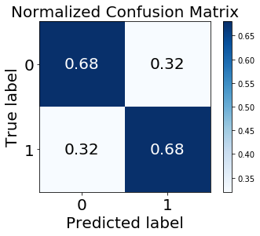

```python
#predict the target use test features
y_pred = lr_fitted.best_estimator_.predict(X_test)
#make the confusion matrix for test data
skplt.metrics.plot_confusion_matrix(
    y_test,
    y_pred,
    normalize = True,
    text_fontsize = 20,
    title_fontsize= 20)
plt.show()
```

```
AUC score: 0.6822388606493567
```

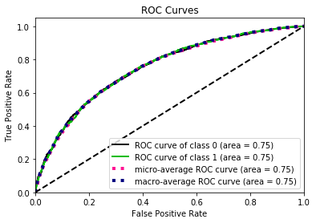

```python
#compute the auc
print("AUC score:" , roc_auc_score(y_test, y_pred))
#make the ROC curves
lr_probas = lr_fitted.predict_proba(X_test)
skplt.metrics.plot_roc(y_test, lr_probas)
plt.show()
```

## Multilayer perceptron

For multilayer perceptron, the hyperparameters we fine tune are: *hidden_layer_sizes and activation.*

```python
param_grid = [{'MLPClassifier__hidden_layer_sizes': [10, 50, 100],
               'MLPClassifier__activation': ['identity', 'logistic', 'tanh', 'relu']}]
```

```python
mlp_pipe = Pipeline([('StandardScaler', StandardScaler()),
                      ("MLPClassifier",MLPClassifier())])

mlp_gs = GridSearchCV(estimator=mlp_pipe,
                  param_grid=param_grid,
                  scoring='f1',
                  n_jobs=-1,
                  cv=StratifiedKFold(n_splits=10,shuffle=True,random_state=0))

mlp_fitted = mlp_gs.fit(X_train, y_train)


# Print the best settings
print('%-15s' % 'best_score:', mlp_fitted.best_score_)
print('%-15s' % 'std:', mlp_fitted.cv_results_["std_test_score"][mlp_fitted.best_index_])
print('%-15s' % 'best_params:'.format(20), mlp_fitted.best_params_, end='\n\n')
```

```
best_score:     0.9606790554970879
std:            0.0015194402708749969
best_params:    {'MLPClassifier__activation': 'logistic', 'MLPClassifier__hidden_layer_sizes': 100}
```

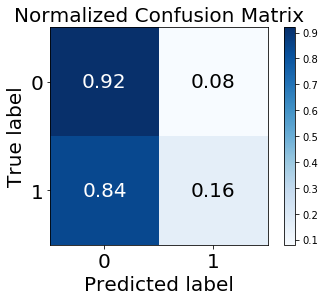

```python
#predict the target use test features
y_pred = mlp_fitted.best_estimator_.predict(X_test)
skplt.metrics.plot_confusion_matrix(
    y_test,
    y_pred,
    normalize = True,
    text_fontsize = 20,
    title_fontsize= 20)
plt.show()
```

```
AUC score: 0.5415891987605136
```

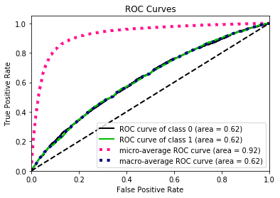

```python
#compute the auc
print("AUC score:" , roc_auc_score(y_test, y_pred))
#make the ROC curves
mlp_probas = mlp_fitted.predict_proba(X_test)
skplt.metrics.plot_roc(y_test, mlp_probas)
plt.show()
```

## Decision Tree

#### For Decision tree, the hyperparameters we fine tune are: *max_depth and min_samples_split.*

```python
max_depth = range(10,91,20)
min_samples_split = range(10,91,20)

# Implement me
# Hint: you should use the above eta_range and C_range
param_grid = [{'DecisionTreeClassifier__max_depth':max_depth,
               'DecisionTreeClassifier__min_samples_split':min_samples_split}]
```

```python
tree_pipe = Pipeline([('StandardScaler', StandardScaler()),
                      ("DecisionTreeClassifier", DecisionTreeClassifier(criterion = "gini"))])

tree_gs = GridSearchCV(estimator = tree_pipe,
                  param_grid=param_grid,
                  scoring='f1',
                  n_jobs=-1,
                  cv=StratifiedKFold(n_splits=10,shuffle=True,random_state=0))

tree_fitted = tree_gs.fit(X_train, y_train)

# Print the best settings
print('%-15s' % 'best_score:', tree_fitted.best_score_)
print('%-15s' % 'std:', tree_fitted.cv_results_["std_test_score"][tree_fitted.best_index_])
print('%-15s' % 'best_params:'.format(20), tree_fitted.best_params_, end='\n\n')
```

```
best_score:     0.9584954795763723
std:            0.0019912512014958693
best_params:    {'DecisionTreeClassifier__max_depth': 70, 'DecisionTreeClassifier__min_samples_split': 10}
```

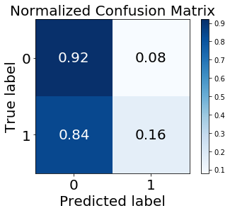

```python
#predict the target use test features
y_pred = tree_fitted.best_estimator_.predict(X_test)
skplt.metrics.plot_confusion_matrix(
    y_test,
    y_pred,
    normalize = True,
    text_fontsize = 20,
    title_fontsize= 20)
plt.show()
```

```
AUC score: 0.5433119374354434
```

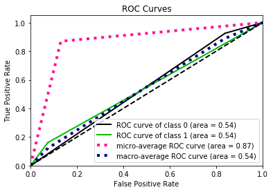

```python
#compute the auc
print("AUC score:" , roc_auc_score(y_test, y_pred))
#make the ROC curves
tree_probas = tree_fitted.predict_proba(X_test)
skplt.metrics.plot_roc(y_test,tree_probas)
plt.show()
```

## Random forest

#### For Random forest, the hyperparameters we fine tune are: *n_estimators, max_depth and max_leaf_nodes.*

```python
#Param for Random Forest
n_estimators = range(50,111,20)
max_depth = range(50,131,20)
max_leaf_nodes = range(50, 131, 20)

# Implement me
# Hint: you should use the above eta_range and C_range
param_grid = [{"RandomForestClassifier__n_estimators":n_estimators,
               "RandomForestClassifier__max_depth":max_depth,
               "RandomForestClassifier__max_leaf_nodes":max_leaf_nodes}]
```

```python
rf_pipe = Pipeline([('StandardScaler', StandardScaler()),
                      ("RandomForestClassifier", RandomForestClassifier(criterion = "gini"))])

rf_gs = GridSearchCV(estimator = rf_pipe,
                  param_grid=param_grid,
                  scoring='f1',
                  n_jobs=-1,
                  cv=StratifiedKFold(n_splits=10,shuffle=True,random_state=0))

rf_fitted = rf_gs.fit(X_train, y_train)

# Print the best settings
print('%-15s' % 'best_score:', rf_fitted.best_score_)
print('%-15s' % 'std:', rf_fitted.cv_results_["std_test_score"][rf_fitted.best_index_])
print('%-15s' % 'best_params:'.format(20), rf_fitted.best_params_, end='\n\n')
```

```
best_score:     0.7466884505962368
std:            0.004639937736989228
best_params:    {'RandomForestClassifier__max_depth': 50, 'RandomForestClassifier__max_leaf_nodes': 130, 'RandomForestClassifier__n_estimators': 110}
```

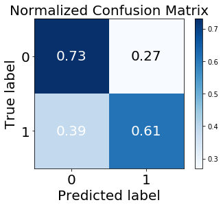

```python
#predict the target use test features
y_pred = rf_fitted.best_estimator_.predict(X_test)
skplt.metrics.plot_confusion_matrix(
    y_test,
    y_pred,
    normalize = True,
    text_fontsize = 20,
    title_fontsize= 20)
plt.show()
```

```
AUC score: 0.6721457719568724
```

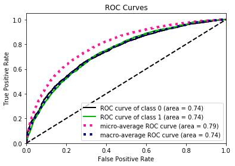

```python
#compute the auc
print("AUC score:" , roc_auc_score(y_test, y_pred))
#make the ROC curves
rf_probas = rf_fitted.predict_proba(X_test)
skplt.metrics.plot_roc(y_test, rf_probas)
plt.show()
```

# xgboost

#### For XGboost, the hyperparameters we fine tune are: *eta, gamma and lambda.*

```python
param_grid = [{'XGBClassifier__eta': [10 ** i for i in range(-4, 1)],
               'XGBClassifier__gamma': [0, 10, 100],
               'XGBClassifier__lambda': [10 ** i for i in range(-4, 5)]}]
```

```python
xg_pipe = Pipeline([('StandardScaler', StandardScaler()),
                      ("XGBClassifier",XGBClassifier())])

xg_gs = GridSearchCV(estimator = xg_pipe,
                  param_grid=param_grid,
                  scoring='f1',
                  n_jobs=-1,
                  cv=StratifiedKFold(n_splits=10,shuffle=True,random_state=0))

xg_fitted = xg_gs.fit(X_train, y_train)

# Print the best settings
print('%-15s' % 'best_score:', xg_fitted.best_score_)
print('%-15s' % 'std:', xg_fitted.cv_results_["std_test_score"][xg_fitted.best_index_])
print('%-15s' % 'best_params:'.format(20), xg_fitted.best_params_, end='\n\n')
```

```
best_score:     0.7034882821082507
std:            0.0034843677632812853
best_params:    {'XGBClassifier__eta': 0.0001, 'XGBClassifier__gamma': 10, 'XGBClassifier__lambda': 0.0001}
```

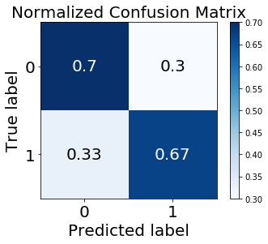

```python
#predict the target use test features
y_pred = xg_fitted.best_estimator_.predict(X_test)
skplt.metrics.plot_confusion_matrix(
    y_test,
    y_pred,
    normalize = True,
    text_fontsize = 20,
    title_fontsize= 20)
plt.show()
```

```
AUC score: 0.6854457012308366
```

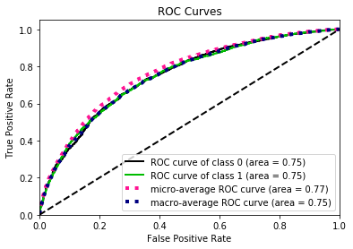

```python
#compute the auc
print("AUC score:" , roc_auc_score(y_test, y_pred))
#make the ROC curves
xg_probas = xg_fitted.predict_proba(X_test)
skplt.metrics.plot_roc(y_test, xg_probas)
plt.show()
```

## KNN

#### For KNN, the hyperparameters we fine tune is: *n_neighbors.*

```python
param_grid = [{'KNeighborsClassifier__n_neighbors': list(range(1, 11))}]
```

```python
knn_pipe = Pipeline([('StandardScaler', StandardScaler()),
                      ("KNeighborsClassifier",KNeighborsClassifier())])

knn_gs = GridSearchCV(estimator = knn_pipe,
                  param_grid=param_grid,
                  scoring='f1',
                  n_jobs=-1,
                  cv=StratifiedKFold(n_splits=10,shuffle=True,random_state=0))

knn_fitted = knn_gs.fit(X_train, y_train)

# Print the best settings
print('%-15s' % 'best_score:', knn_fitted.best_score_)
print('%-15s' % 'std:', knn_fitted.cv_results_["std_test_score"][knn_fitted.best_index_])
print('%-15s' % 'best_params:'.format(20), knn_fitted.best_params_, end='\n\n')
```

```
best_score:     0.9640380974647565
std:            0.0022469094759983727
best_params:    {'KNeighborsClassifier__n_neighbors': 1}
```

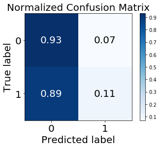

```python
#predict the target use test features
y_pred = knn_fitted.best_estimator_.predict(X_test)
skplt.metrics.plot_confusion_matrix(
    y_test,
    y_pred,
    normalize = True,
    text_fontsize = 20,
    title_fontsize= 20)
plt.show()
```

```
AUC score: 0.5209762482636504
```

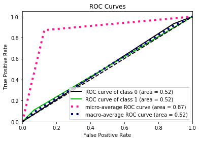

```python
#compute the auc
print("AUC score:" , roc_auc_score(y_test, y_pred))
#make the ROC curves
knn_probas = knn_fitted.predict_proba(X_test)
skplt.metrics.plot_roc(y_test, knn_probas)
plt.show()
```

# Model Selection

[figure not shown]

```python
Image(filename='rank.png',width=600, height=300)
```

In the analysis of the model training, we get a very high training score over 90% in the model multilayer perceptron, decision tree and KNN. However, when we use test data set to check the model it shows very low score, only 50%. So it is obvouis that these three models are not good as the problem of overfitting arises.

Compare with the other models, we can see that Logistic regression have the lowest false negative score, which means the applicant not make the repayment but predicted as make the payment score are low. So we can conclude that the best model for our data is Logistic regression.

# Feature Importance

### Finally, we use the random forest to generate the important features of our model. As the plot shows below:

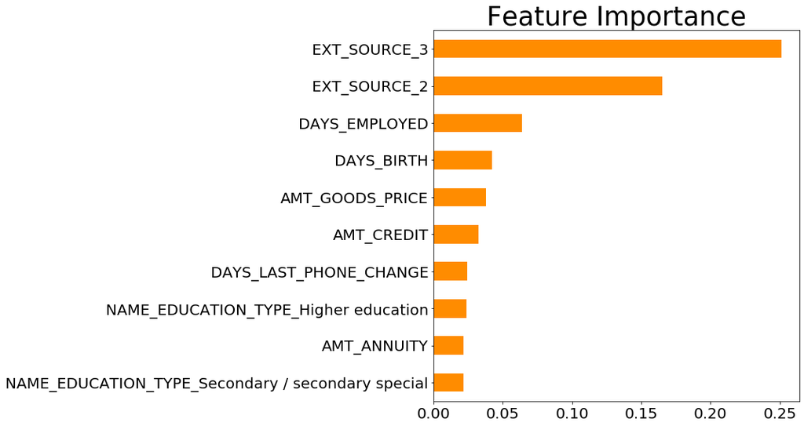

```python
# Convert the importances into one-dimensional 1darray with corresponding df column names as axis labels
f_importances = pd.Series(rf_fitted.best_estimator_.named_steps['RandomForestClassifier'].feature_importances_, feature_value_names)

# Sort the array in descending order of the importances
f_importances = f_importances.sort_values(ascending=False)[:10]

# Draw the bar Plot from f_importances
fig, ax = plt.subplots(figsize=(15,8))
f_importances.plot(x='Features', y='Importance', kind='barh', rot=0, fontsize=20, color = "darkorange")
ax.invert_yaxis()
plt.title('Feature Importance', fontsize=35)

# Show the plot
plt.tight_layout()
plt.show()
```

[figure not shown]

```python
Image(filename='models.png',width=1000, height=400)
```

Finally, we use the Random forest classifier to find out the most important features for our model. From the plot, we can see that, the top 2 important features are external_sources_3 and external_sources_2, these two features are far more ahead of other features, but the data provider does not give us any infortmation about these two features.

In a word, whether an applicant can repay a loan is mainly based on whether he has enough money or whether he has possible to be a fraudulent customer.

# Conclusion